# Optimal Treatment Analysis

## Outcome Variable

**Outcome Variable:** whz

## Predictor Variables

**Intervention Variable:** hfoodsec

**Adjustment Set:**

- arm
- sex
- W_mage
- meducyrs
- feducyrs
- hhwealth_quart
- vagbrth
- W_nrooms
- W_nchldlt5
- brthmon
- W_parity
- impfloor
- impsan
- safeh20
- delta_W_mage
- delta_meducyrs
- delta_feducyrs
- delta_hhwealth_quart
- delta_vagbrth
- delta_W_nrooms
- delta_W_nchldlt5
- delta_brthmon
- delta_W_parity
- delta_impfloor
- delta_impsan
- delta_safeh20

## Stratifying Variables

The analysis was stratified on these variable(s):

- agecat
- studyid
- country

## Data Summary

| agecat | studyid | country | hfoodsec | n_cell | n |
| --- | --- | --- | --- | --- | --- |
| Birth | ki0047075b-MAL-ED | BANGLADESH | Food Secure | 151 | 178 |
| Birth | ki0047075b-MAL-ED | BANGLADESH | Mildly Food Insecure | 3 | 178 |
| Birth | ki0047075b-MAL-ED | BANGLADESH | Food Insecure | 24 | 178 |
| Birth | ki0047075b-MAL-ED | BRAZIL | Food Secure | 0 | 102 |
| Birth | ki0047075b-MAL-ED | BRAZIL | Mildly Food Insecure | 11 | 102 |
| Birth | ki0047075b-MAL-ED | BRAZIL | Food Insecure | 91 | 102 |
| Birth | ki0047075b-MAL-ED | INDIA | Food Secure | 151 | 167 |
| Birth | ki0047075b-MAL-ED | INDIA | Mildly Food Insecure | 2 | 167 |
| Birth | ki0047075b-MAL-ED | INDIA | Food Insecure | 14 | 167 |
| Birth | ki0047075b-MAL-ED | NEPAL | Food Secure | 75 | 96 |
| Birth | ki0047075b-MAL-ED | NEPAL | Mildly Food Insecure | 9 | 96 |
| Birth | ki0047075b-MAL-ED | NEPAL | Food Insecure | 12 | 96 |
| Birth | ki0047075b-MAL-ED | PERU | Food Secure | 26 | 105 |
| Birth | ki0047075b-MAL-ED | PERU | Mildly Food Insecure | 24 | 105 |
| Birth | ki0047075b-MAL-ED | PERU | Food Insecure | 55 | 105 |
| Birth | ki0047075b-MAL-ED | SOUTH AFRICA | Food Secure | 106 | 193 |
| Birth | ki0047075b-MAL-ED | SOUTH AFRICA | Mildly Food Insecure | 17 | 193 |
| Birth | ki0047075b-MAL-ED | SOUTH AFRICA | Food Insecure | 70 | 193 |
| Birth | ki1017093-NIH-Birth | BANGLADESH | Food Secure | 3 | 28 |
| Birth | ki1017093-NIH-Birth | BANGLADESH | Mildly Food Insecure | 21 | 28 |
| Birth | ki1017093-NIH-Birth | BANGLADESH | Food Insecure | 4 | 28 |
| Birth | ki1017093c-NIH-Crypto | BANGLADESH | Food Secure | 14 | 23 |
| Birth | ki1017093c-NIH-Crypto | BANGLADESH | Mildly Food Insecure | 6 | 23 |
| Birth | ki1017093c-NIH-Crypto | BANGLADESH | Food Insecure | 3 | 23 |
| Birth | kiGH5241-JiVitA-3 | BANGLADESH | Food Secure | 2478 | 5069 |
| Birth | kiGH5241-JiVitA-3 | BANGLADESH | Mildly Food Insecure | 1688 | 5069 |
| Birth | kiGH5241-JiVitA-3 | BANGLADESH | Food Insecure | 903 | 5069 |
| Birth | kiGH5241-JiVitA-4 | BANGLADESH | Food Secure | 95 | 183 |
| Birth | kiGH5241-JiVitA-4 | BANGLADESH | Mildly Food Insecure | 61 | 183 |
| Birth | kiGH5241-JiVitA-4 | BANGLADESH | Food Insecure | 27 | 183 |

[output cut: 66 more lines]

The following strata were considered:

- agecat: 24 months, studyid: ki0047075b-MAL-ED, country: BANGLADESH
- agecat: 24 months, studyid: ki0047075b-MAL-ED, country: BRAZIL
- agecat: 24 months, studyid: ki0047075b-MAL-ED, country: INDIA
- agecat: 24 months, studyid: ki0047075b-MAL-ED, country: NEPAL
- agecat: 24 months, studyid: ki0047075b-MAL-ED, country: PERU
- agecat: 24 months, studyid: ki0047075b-MAL-ED, country: SOUTH AFRICA
- agecat: 24 months, studyid: ki1017093-NIH-Birth, country: BANGLADESH
- agecat: 24 months, studyid: ki1017093c-NIH-Crypto, country: BANGLADESH
- agecat: 24 months, studyid: ki1113344-GMS-Nepal, country: NEPAL
- agecat: 24 months, studyid: kiGH5241-JiVitA-3, country: BANGLADESH
- agecat: 24 months, studyid: kiGH5241-JiVitA-4, country: BANGLADESH
- agecat: 6 months, studyid: ki0047075b-MAL-ED, country: BANGLADESH
- agecat: 6 months, studyid: ki0047075b-MAL-ED, country: BRAZIL
- agecat: 6 months, studyid: ki0047075b-MAL-ED, country: INDIA
- agecat: 6 months, studyid: ki0047075b-MAL-ED, country: NEPAL
- agecat: 6 months, studyid: ki0047075b-MAL-ED, country: PERU
- agecat: 6 months, studyid: ki0047075b-MAL-ED, country: SOUTH AFRICA
- agecat: 6 months, studyid: ki1017093-NIH-Birth, country: BANGLADESH
- agecat: 6 months, studyid: ki1017093c-NIH-Crypto, country: BANGLADESH
- agecat: 6 months, studyid: ki1113344-GMS-Nepal, country: NEPAL
- agecat: 6 months, studyid: kiGH5241-JiVitA-3, country: BANGLADESH
- agecat: 6 months, studyid: kiGH5241-JiVitA-4, country: BANGLADESH
- agecat: Birth, studyid: ki0047075b-MAL-ED, country: BANGLADESH
- agecat: Birth, studyid: ki0047075b-MAL-ED, country: BRAZIL
- agecat: Birth, studyid: ki0047075b-MAL-ED, country: INDIA
- agecat: Birth, studyid: ki0047075b-MAL-ED, country: NEPAL
- agecat: Birth, studyid: ki0047075b-MAL-ED, country: PERU
- agecat: Birth, studyid: ki0047075b-MAL-ED, country: SOUTH AFRICA
- agecat: Birth, studyid: ki1017093-NIH-Birth, country: BANGLADESH
- agecat: Birth, studyid: ki1017093c-NIH-Crypto, country: BANGLADESH
- agecat: Birth, studyid: kiGH5241-JiVitA-3, country: BANGLADESH
- agecat: Birth, studyid: kiGH5241-JiVitA-4, country: BANGLADESH

### Dropped Strata

Some strata were dropped due to rare outcomes:

- agecat: Birth, studyid: ki0047075b-MAL-ED, country: BANGLADESH
- agecat: Birth, studyid: ki0047075b-MAL-ED, country: BRAZIL
- agecat: Birth, studyid: ki0047075b-MAL-ED, country: INDIA
- agecat: Birth, studyid: ki1017093-NIH-Birth, country: BANGLADESH
- agecat: Birth, studyid: ki1017093c-NIH-Crypto, country: BANGLADESH
- agecat: 6 months, studyid: ki0047075b-MAL-ED, country: BANGLADESH
- agecat: 6 months, studyid: ki0047075b-MAL-ED, country: BRAZIL
- agecat: 24 months, studyid: ki0047075b-MAL-ED, country: BANGLADESH
- agecat: 24 months, studyid: ki0047075b-MAL-ED, country: BRAZIL

## Methods Detail

We’re interested in the causal parameters $E[Y_a]$ for all values of $a \in \mathcal{A}$. These parameters represent the mean outcome if, possibly contrary to fact, we intervened to set all units to have $A=a$. Under the randomization and positivity assumptions, these are identified by the statistical parameters $\psi_a=E_W[E_{Y|A,W}(Y|A=a,W)]$. In addition, we’re interested in the mean of $Y$, $E[Y]$ under no intervention (the observed mean). We will estimate these parameters by using SuperLearner to fit the relevant likelihood factors – $E_{Y|A,W}(Y|A=a,W)$ and $p(A=a|W)$, and then updating our likelihood fit using a joint TMLE.

For unadjusted analyses ($W=\{\}$), initial likelihoods were estimated using Lrnr_glm to estimate the simple $E(Y|A)$ and Lrnr_mean to estimate $p(A)$. For adjusted analyses, a small library containing Lrnr_glmnet, Lrnr_xgboost, and Lrnr_mean was used.

# Results Detail

## Results Plots

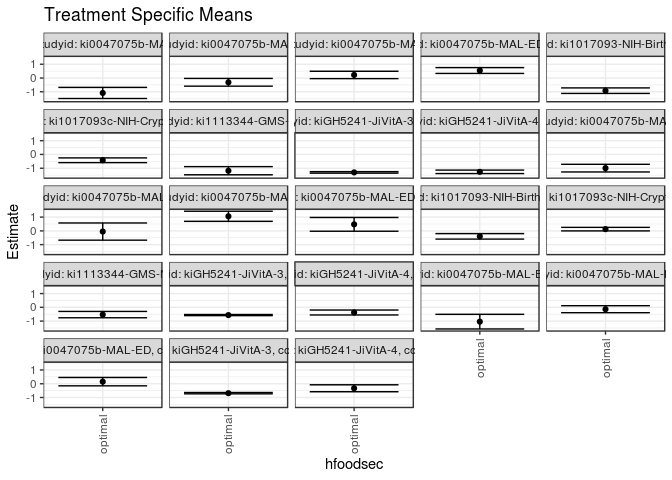

## Results Table

### Parameter: TSM

| agecat | studyid | country | intervention_level | baseline_level | estimate | ci_lower | ci_upper |
| --- | --- | --- | --- | --- | --- | --- | --- |
| Birth | ki0047075b-MAL-ED | NEPAL | optimal | observed | -1.0409059 | -1.5727874 | -0.5090243 |
| Birth | ki0047075b-MAL-ED | PERU | optimal | observed | -0.1376293 | -0.3925321 | 0.1172735 |
| Birth | ki0047075b-MAL-ED | SOUTH AFRICA | optimal | observed | 0.1514985 | -0.1528814 | 0.4558785 |
| Birth | kiGH5241-JiVitA-3 | BANGLADESH | optimal | observed | -0.6861432 | -0.7341446 | -0.6381418 |
| Birth | kiGH5241-JiVitA-4 | BANGLADESH | optimal | observed | -0.3289208 | -0.5806219 | -0.0772198 |
| 6 months | ki0047075b-MAL-ED | INDIA | optimal | observed | -0.9938179 | -1.2723612 | -0.7152746 |
| 6 months | ki0047075b-MAL-ED | NEPAL | optimal | observed | -0.0483935 | -0.6727345 | 0.5759475 |
| 6 months | ki0047075b-MAL-ED | PERU | optimal | observed | 1.0605282 | 0.6936985 | 1.4273579 |
| 6 months | ki0047075b-MAL-ED | SOUTH AFRICA | optimal | observed | 0.4733429 | -0.0270911 | 0.9737769 |
| 6 months | ki1017093-NIH-Birth | BANGLADESH | optimal | observed | -0.3977855 | -0.5982152 | -0.1973558 |
| 6 months | ki1017093c-NIH-Crypto | BANGLADESH | optimal | observed | 0.1267037 | -0.0003722 | 0.2537796 |
| 6 months | ki1113344-GMS-Nepal | NEPAL | optimal | observed | -0.5290326 | -0.7576151 | -0.3004501 |
| 6 months | kiGH5241-JiVitA-3 | BANGLADESH | optimal | observed | -0.5652531 | -0.6054392 | -0.5250670 |
| 6 months | kiGH5241-JiVitA-4 | BANGLADESH | optimal | observed | -0.3773814 | -0.5567480 | -0.1980148 |
| 24 months | ki0047075b-MAL-ED | INDIA | optimal | observed | -1.0848356 | -1.4886529 | -0.6810184 |
| 24 months | ki0047075b-MAL-ED | NEPAL | optimal | observed | -0.3111815 | -0.5925737 | -0.0297893 |
| 24 months | ki0047075b-MAL-ED | PERU | optimal | observed | 0.2233202 | -0.0444490 | 0.4910894 |
| 24 months | ki0047075b-MAL-ED | SOUTH AFRICA | optimal | observed | 0.5453614 | 0.3334165 | 0.7573062 |
| 24 months | ki1017093-NIH-Birth | BANGLADESH | optimal | observed | -0.9197353 | -1.1209768 | -0.7184938 |
| 24 months | ki1017093c-NIH-Crypto | BANGLADESH | optimal | observed | -0.4210357 | -0.5928482 | -0.2492231 |
| 24 months | ki1113344-GMS-Nepal | NEPAL | optimal | observed | -1.1814242 | -1.4777797 | -0.8850686 |
| 24 months | kiGH5241-JiVitA-3 | BANGLADESH | optimal | observed | -1.3035061 | -1.3573217 | -1.2496904 |
| 24 months | kiGH5241-JiVitA-4 | BANGLADESH | optimal | observed | -1.2623030 | -1.3889784 | -1.1356275 |

### Parameter: E(Y)

| agecat | studyid | country | intervention_level | baseline_level | estimate | ci_lower | ci_upper |
| --- | --- | --- | --- | --- | --- | --- | --- |
| Birth | ki0047075b-MAL-ED | NEPAL | observed | observed | -0.9503125 | -1.1412124 | -0.7594126 |
| Birth | ki0047075b-MAL-ED | PERU | observed | observed | -0.0395238 | -0.2249300 | 0.1458824 |
| Birth | ki0047075b-MAL-ED | SOUTH AFRICA | observed | observed | 0.0036788 | -0.1626160 | 0.1699735 |
| Birth | kiGH5241-JiVitA-3 | BANGLADESH | observed | observed | -0.7378181 | -0.7714138 | -0.7042224 |
| Birth | kiGH5241-JiVitA-4 | BANGLADESH | observed | observed | -0.2849727 | -0.4444441 | -0.1255013 |
| 6 months | ki0047075b-MAL-ED | INDIA | observed | observed | -0.7155110 | -0.8495147 | -0.5815073 |
| 6 months | ki0047075b-MAL-ED | NEPAL | observed | observed | 0.1289063 | -0.0638567 | 0.3216692 |
| 6 months | ki0047075b-MAL-ED | PERU | observed | observed | 0.9790991 | 0.7644567 | 1.1937415 |
| 6 months | ki0047075b-MAL-ED | SOUTH AFRICA | observed | observed | 0.5422442 | 0.3806254 | 0.7038629 |
| 6 months | ki1017093-NIH-Birth | BANGLADESH | observed | observed | -0.4389101 | -0.5279432 | -0.3498771 |
| 6 months | ki1017093c-NIH-Crypto | BANGLADESH | observed | observed | 0.0297622 | -0.0491685 | 0.1086930 |
| 6 months | ki1113344-GMS-Nepal | NEPAL | observed | observed | -0.6028654 | -0.6902793 | -0.5154516 |
| 6 months | kiGH5241-JiVitA-3 | BANGLADESH | observed | observed | -0.5900795 | -0.6175675 | -0.5625915 |
| 6 months | kiGH5241-JiVitA-4 | BANGLADESH | observed | observed | -0.3630258 | -0.4340802 | -0.2919714 |
| 24 months | ki0047075b-MAL-ED | INDIA | observed | observed | -0.9595519 | -1.0781202 | -0.8409836 |
| 24 months | ki0047075b-MAL-ED | NEPAL | observed | observed | -0.2757812 | -0.4379560 | -0.1136065 |
| 24 months | ki0047075b-MAL-ED | PERU | observed | observed | 0.0979907 | -0.0798724 | 0.2758537 |
| 24 months | ki0047075b-MAL-ED | SOUTH AFRICA | observed | observed | 0.4264693 | 0.3032402 | 0.5496984 |
| 24 months | ki1017093-NIH-Birth | BANGLADESH | observed | observed | -0.9115790 | -1.0095022 | -0.8136559 |
| 24 months | ki1017093c-NIH-Crypto | BANGLADESH | observed | observed | -0.6103502 | -0.7050157 | -0.5156847 |
| 24 months | ki1113344-GMS-Nepal | NEPAL | observed | observed | -1.1257803 | -1.2146168 | -1.0369438 |
| 24 months | kiGH5241-JiVitA-3 | BANGLADESH | observed | observed | -1.2943917 | -1.3273407 | -1.2614428 |
| 24 months | kiGH5241-JiVitA-4 | BANGLADESH | observed | observed | -1.2268123 | -1.2868189 | -1.1668056 |

### Parameter: PAR

| agecat | studyid | country | intervention_level | baseline_level | estimate | ci_lower | ci_upper |
| --- | --- | --- | --- | --- | --- | --- | --- |
| Birth | ki0047075b-MAL-ED | NEPAL | optimal | observed | 0.0905934 | -0.4300522 | 0.6112390 |
| Birth | ki0047075b-MAL-ED | PERU | optimal | observed | 0.0981055 | -0.1079199 | 0.3041309 |
| Birth | ki0047075b-MAL-ED | SOUTH AFRICA | optimal | observed | -0.1478198 | -0.4598784 | 0.1642389 |
| Birth | kiGH5241-JiVitA-3 | BANGLADESH | optimal | observed | -0.0516749 | -0.0859830 | -0.0173668 |
| Birth | kiGH5241-JiVitA-4 | BANGLADESH | optimal | observed | 0.0439482 | -0.1974610 | 0.2853573 |
| 6 months | ki0047075b-MAL-ED | INDIA | optimal | observed | 0.2783069 | 0.0256271 | 0.5309867 |
| 6 months | ki0047075b-MAL-ED | NEPAL | optimal | observed | 0.1772998 | -0.3858591 | 0.7404587 |
| 6 months | ki0047075b-MAL-ED | PERU | optimal | observed | -0.0814291 | -0.3823724 | 0.2195141 |
| 6 months | ki0047075b-MAL-ED | SOUTH AFRICA | optimal | observed | 0.0689012 | -0.4107057 | 0.5485082 |
| 6 months | ki1017093-NIH-Birth | BANGLADESH | optimal | observed | -0.0411246 | -0.2254069 | 0.1431576 |
| 6 months | ki1017093c-NIH-Crypto | BANGLADESH | optimal | observed | -0.0969415 | -0.1928300 | -0.0010530 |
| 6 months | ki1113344-GMS-Nepal | NEPAL | optimal | observed | -0.0738328 | -0.2906689 | 0.1430033 |
| 6 months | kiGH5241-JiVitA-3 | BANGLADESH | optimal | observed | -0.0248264 | -0.0510773 | 0.0014245 |
| 6 months | kiGH5241-JiVitA-4 | BANGLADESH | optimal | observed | 0.0143556 | -0.1508335 | 0.1795447 |
| 24 months | ki0047075b-MAL-ED | INDIA | optimal | observed | 0.1252837 | -0.2579915 | 0.5085590 |
| 24 months | ki0047075b-MAL-ED | NEPAL | optimal | observed | 0.0354003 | -0.1736560 | 0.2444565 |
| 24 months | ki0047075b-MAL-ED | PERU | optimal | observed | -0.1253295 | -0.3895286 | 0.1388695 |
| 24 months | ki0047075b-MAL-ED | SOUTH AFRICA | optimal | observed | -0.1188921 | -0.2895025 | 0.0517184 |
| 24 months | ki1017093-NIH-Birth | BANGLADESH | optimal | observed | 0.0081563 | -0.1759021 | 0.1922147 |
| 24 months | ki1017093c-NIH-Crypto | BANGLADESH | optimal | observed | -0.1893145 | -0.3399303 | -0.0386987 |
| 24 months | ki1113344-GMS-Nepal | NEPAL | optimal | observed | 0.0556439 | -0.2216845 | 0.3329723 |
| 24 months | kiGH5241-JiVitA-3 | BANGLADESH | optimal | observed | 0.0091143 | -0.0327170 | 0.0509457 |
| 24 months | kiGH5241-JiVitA-4 | BANGLADESH | optimal | observed | 0.0354907 | -0.0740488 | 0.1450302 |